# Singularity Containers: From Building to Deployment

# Introduction

This document provides information for installing and running containers through a HPC. It will cover building from pre-built containers, installations via a recipe script, developing module files for your containers and running your containers on a HPC.

[figure not shown]

## Why containers?

- **Reproducible results**
  - Version control
- **Environment independent**
  - Works for me, works for you.
- **Easily installation**
  - No sudo permissions on HPC required!
- **Reduce conflicts between software**
  - Pipeline saviour

## Which containers

- Singularity > Docker
  - HPC friendly (no root required for running)
  - Reduce security issues
  - Smaller overhead
  - Segmented recipes
  - Less community
  - Can import dockerfiles anyways

## Caveats

- Learning curve
- Some system-admin knowledge required (apt-get installation methods)
- Developing technology (some bugs fixed required)

# Overview of environment wrapping

Containers and HPC scheduling initially can be quite overwhelming. This diagram is not intended to intimidate but for debugging assistance.

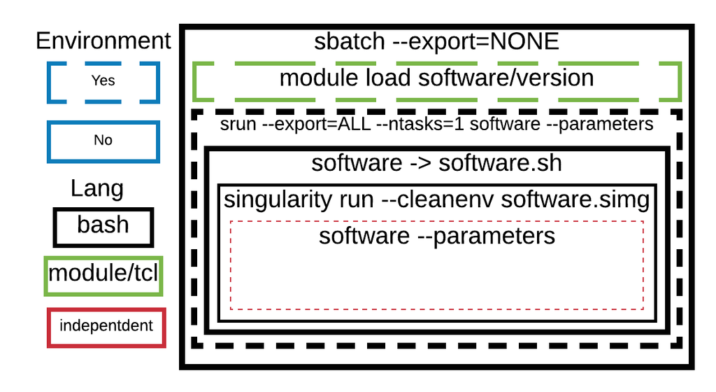

# Installation Overview

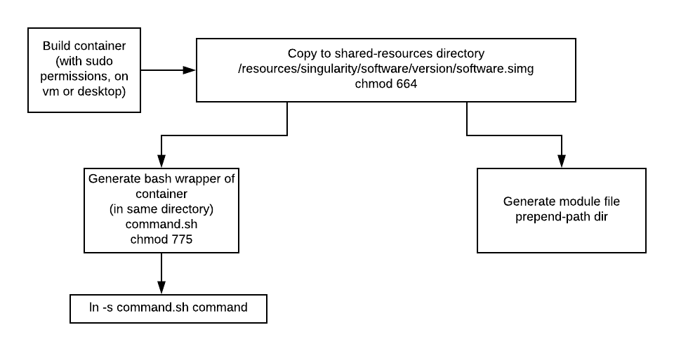